# PCA Example with iris Dataset

Heath Blackmon

## 1. Load and Inspect Data

We’ll use the classic `iris` dataset. It contains 150 flower measurements from three species.

```r
data(iris)
head(iris)
```

```
##   Sepal.Length Sepal.Width Petal.Length Petal.Width Species
## 1          5.1         3.5          1.4         0.2  setosa
## 2          4.9         3.0          1.4         0.2  setosa
## 3          4.7         3.2          1.3         0.2  setosa
## 4          4.6         3.1          1.5         0.2  setosa
## 5          5.0         3.6          1.4         0.2  setosa
## 6          5.4         3.9          1.7         0.4  setosa
```

The variables `Sepal.Length`, `Sepal.Width`, `Petal.Length`, and `Petal.Width` will be used for PCA, while `Species` is a grouping factor.

## 2. Perform PCA with Base R

We’ll use `prcomp()` on the four numeric variables and scale them to equalize variance.

```r
pca_fit <- prcomp(iris[, 1:4], scale. = TRUE)
summary(pca_fit)
```

```
## Importance of components:
##                           PC1    PC2     PC3     PC4
## Standard deviation     1.7084 0.9560 0.38309 0.14393
## Proportion of Variance 0.7296 0.2285 0.03669 0.00518
## Cumulative Proportion  0.7296 0.9581 0.99482 1.00000
```

The **summary** shows how much variance is explained by each principal component (PC).

## 3. Visualize PCA Results (Base Plot)

We can plot the first two principal components using base R. Points are colored by species.

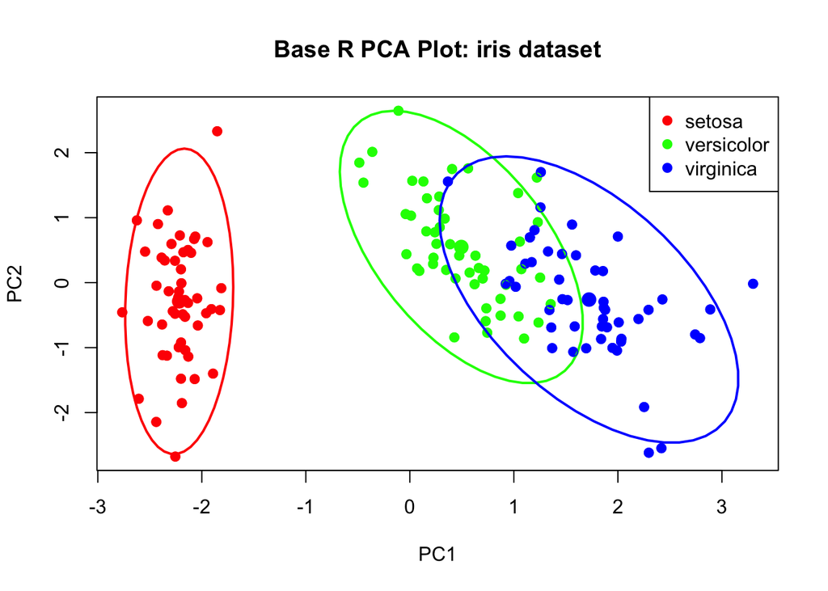

```r
species_colors <- c("setosa" = "red", "versicolor" = "green", "virginica" = "blue")

plot(pca_fit$x[, 1], pca_fit$x[, 2],
     col = species_colors[iris$Species],
     pch = 19,
     xlab = "PC1",
     ylab = "PC2",
     main = "Base R PCA Plot: iris dataset")
legend("topright", legend = names(species_colors), col = species_colors, pch = 19)

for (sp in unique(iris$Species)) {
  dat <- pca_fit$x[iris$Species == sp, 1:2]
  dataEllipse(dat[, 1], dat[, 2],
              levels = 0.95,
              add = TRUE,
              col = species_colors[sp],
              lwd = 2)
}
```

These ellipses represent the regions containing about 95% of points for each species.

## 5. Examine Variable Contributions (FactoMineR)

Now, let’s use **FactoMineR** to see which variables contribute most to each principal component.

```r
res_pca <- PCA(iris[, 1:4], graph = FALSE)

# Contributions to PC1 and PC2
res_pca$var$contrib
```

```
##                  Dim.1       Dim.2     Dim.3     Dim.4
## Sepal.Length 27.150969 14.24440565 51.777574  6.827052
## Sepal.Width   7.254804 85.24748749  5.972245  1.525463
## Petal.Length 33.687936  0.05998389  2.019990 64.232089
## Petal.Width  31.906291  0.44812296 40.230191 27.415396
```

This table shows how much each original variable contributes to each principal component.

## 6. Visualize Contributions (FactoMineR / factoextra)

We can use `fviz_pca_var()` to visualize which variables load most strongly on each PC axis.

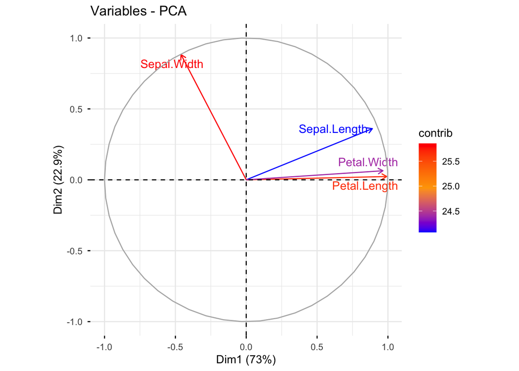

```r
fviz_pca_var(res_pca,
             col.var = "contrib",
             gradient.cols = c("blue", "orange", "red"),
             repel = TRUE)
```

## 7. Compare to Raw Measurements

Finally, let’s compare visually: do the first two PCs separate the species better than any two raw measurements?

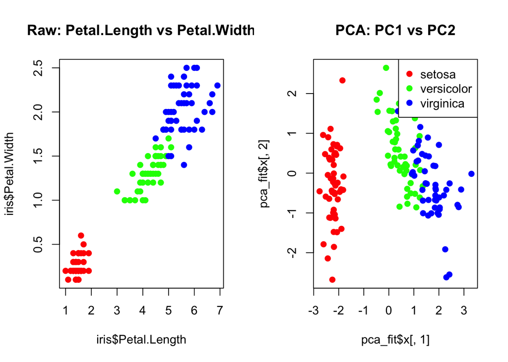

```r
par(mfrow = c(1, 2))

# Raw variables
plot(iris$Petal.Length, iris$Petal.Width,
     col = species_colors[iris$Species],
     pch = 19,
     main = "Raw: Petal.Length vs Petal.Width")

# PCA axes
plot(pca_fit$x[, 1], pca_fit$x[, 2],
     col = species_colors[iris$Species],
     pch = 19,
     main = "PCA: PC1 vs PC2")

legend("topright", legend = names(species_colors), col = species_colors, pch = 19)
```

### Conclusion

- The PCA compresses four correlated variables into two new axes that maximize variance captured.
- The species clusters above are not more distinct in PCA space than in the raw measurement combinations.
- What could explain this? Do other PCs do a better job than 1 and 2?